# CSCI E-63C Week 9 Problem Set

# Problem 1: within/between cluster variation and CH-index (15 points)

Present plots of CH-index as well as (total) within and between cluster variance provided by K-means clustering on scaled WHS data for 2 through 20 clusters. Choose large enough value of `nstart` for better stability of the results across multiple trials and evaluate stability of those results across several runs. Discuss the results and weigh on whether the shapes of the curves suggest specific number of clusters in the data.

```r
raw.data <- read.csv("whs2018_AnnexB-subset-wo-NAs.txt",
                     header = TRUE,
                     sep = "\t")
head(raw.data)
```

```
##                     TotalPopulation LifeExpectancyM LifeExpectancyF
## Afghanistan                   34656            61.0            64.5
## Albania                        2926            74.3            78.6
## Algeria                       40606            75.4            77.4
## Andorra                          77            70.3            76.4
## Angola                        28813            60.3            64.9
## Antigua and Barbuda             101            72.5            77.5
##                     LifeExpectancyB HealthyLifeExpectancy CHEperCapita
## Afghanistan                    62.7                  53.0           60
## Albania                        76.4                  68.1          266
## Algeria                        76.4                  65.5          292
## Andorra                        73.4                  64.9         4316
## Angola                         62.6                  55.8          109
## Antigua and Barbuda            75.0                  67.0          657
##                     CHEpercGDP MaternalMortality BirthsSkilledPersonnel
## Afghanistan               10.3               396                     50
## Albania                    6.8                29                     99
## Algeria                    7.1               140                     97
## Andorra                   12.0                54                     97
## Angola                     2.9               477                     47
## Antigua and Barbuda        4.8                54                    100
##                     ChildMortality NeonatalMortality Tuberculosis HepatitisB
## Afghanistan                   70.4              40.0        189.0       0.50
## Albania                       13.5               6.2         16.0       1.29
## Algeria                       25.2              15.6         70.0       0.22
## Andorra                        2.7               1.1          6.0       0.08
## Angola                        82.5              29.3        370.0       4.85
## Antigua and Barbuda            8.5               3.8          3.4       0.38
##                     NTDinterventions CVDcancerDiabetesCRD Suicide Alcohol
## Afghanistan                 13275429                 29.8     4.7     0.2
## Albania                           21                 17.0     6.3     7.5
## Algeria                            0                 14.2     3.2     0.9
## Andorra                            0                 18.8     7.9    11.3
## Angola                      14419092                 16.5     4.7     6.4
## Antigua and Barbuda              176                 22.6     0.5     7.0
##                     TrafficMortality AdolescentBirth UHCcoverageIndex
## Afghanistan                     15.5           87.00               34
## Albania                         15.1           18.90               62
## Algeria                         23.8            9.00               76
## Andorra                          7.6           44.35               65
```

[output cut: 22 more lines]

```
## Antigua and Barbuda            0.3              0.25       71     14.9
##                     CleanFuel UrbanParticulate NaturalDisaster Homicide
## Afghanistan                32             59.9             0.7      7.4
## Albania                    77             18.2             0.0      4.2
## Algeria                    93             34.5             0.1      4.2
## Andorra                    95             11.5             0.1      5.2
## Angola                     48             28.4             0.1      9.8
## Antigua and Barbuda        95             18.0             0.0      1.8
##                     MajorConflict
## Afghanistan                  37.3
## Albania                       0.1
## Algeria                       0.7
## Andorra                       0.1
## Angola                        0.1
## Antigua and Barbuda           0.0
```

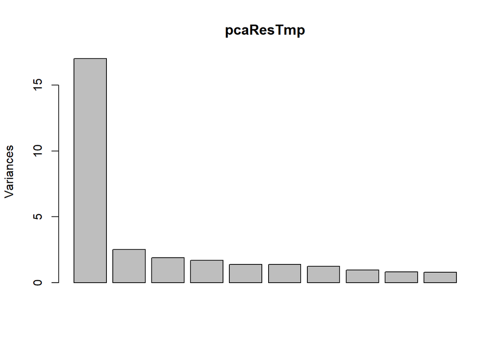

```r
scaled.data <- scale(raw.data)
pcaResTmp <- prcomp(scaled.data)
plot(pcaResTmp)
```

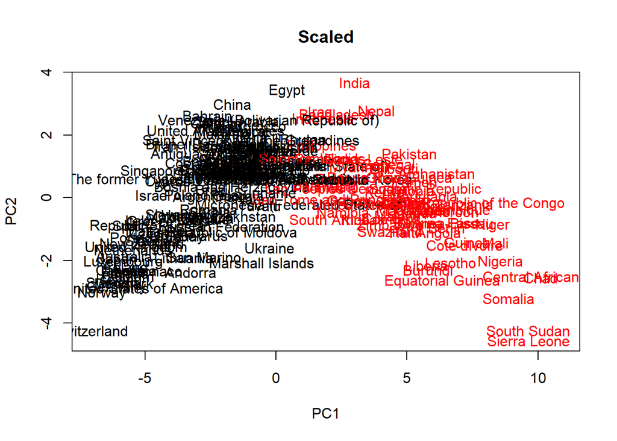

```r
cids <- kmeans(scaled.data,centers=2,nstart=10)$cluster
plot(pcaResTmp$x[,1:2],type="n",main="Scaled")
text(pcaResTmp$x[,1:2],rownames(pcaResTmp$x),col=cids,pch=15+cids)
```

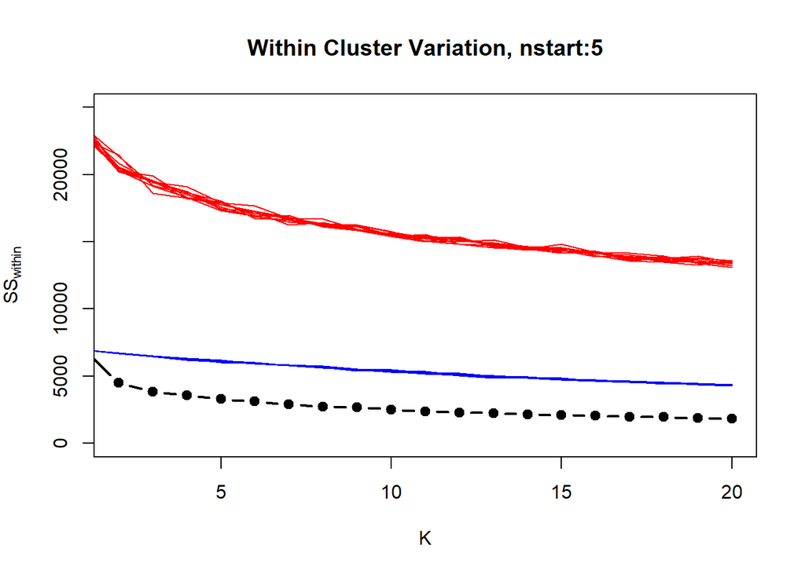

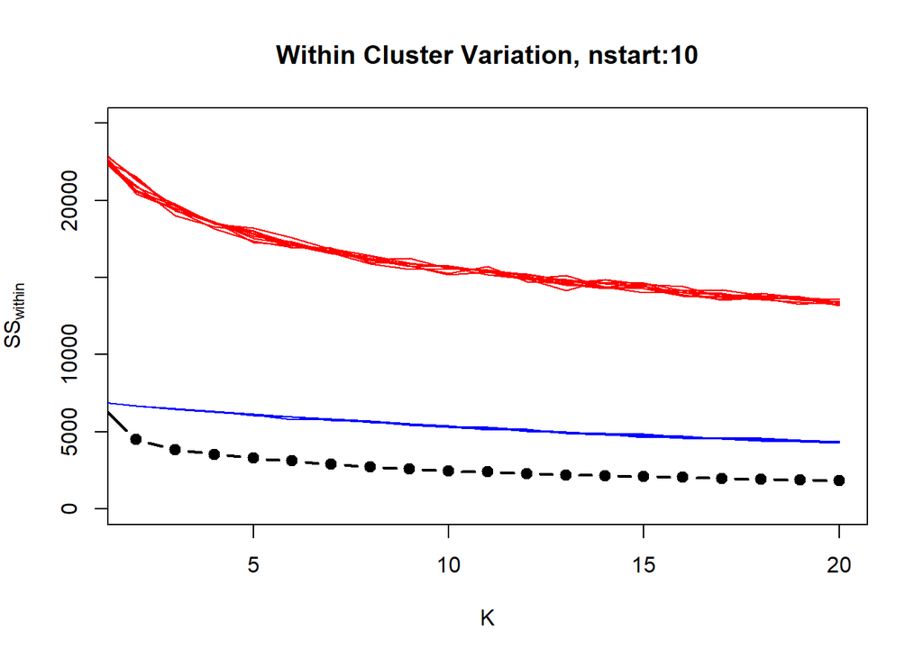

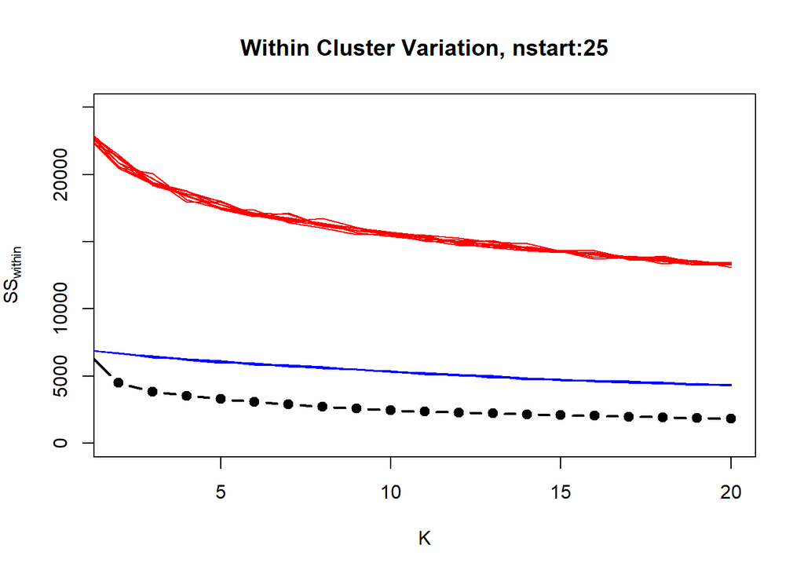

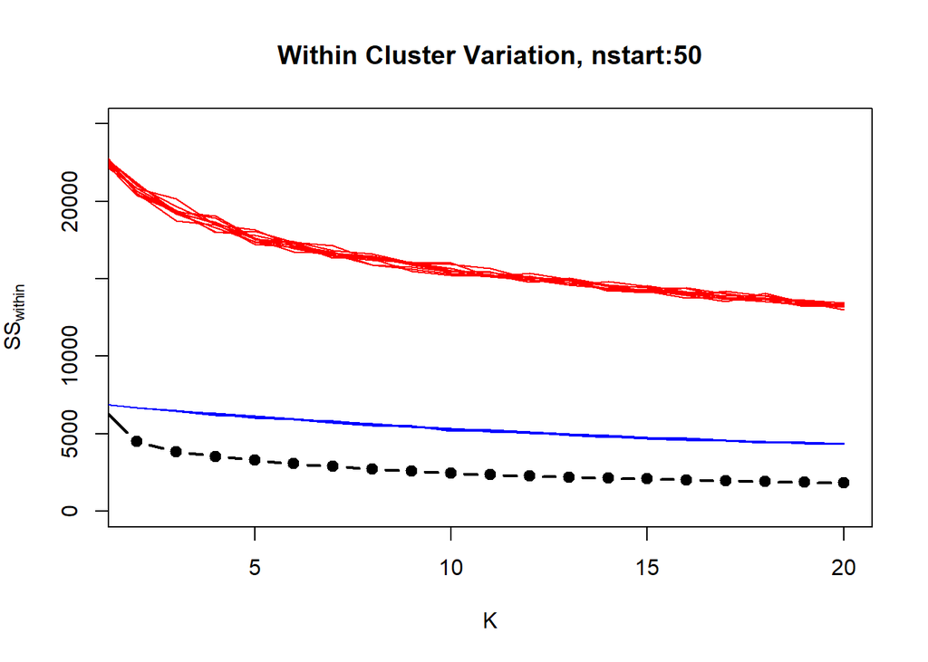

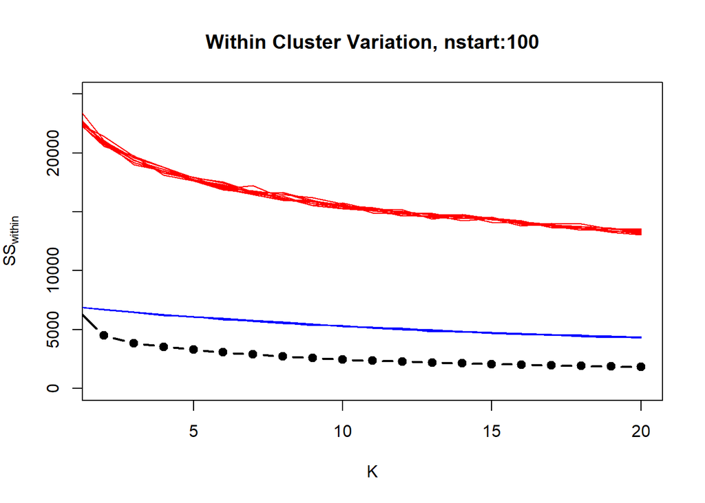

```r
#set.seed(112)
nstarts <- c(5,10,25,50,100)
for (j in nstarts) {
    w=numeric(20)
    for ( k in 1:20 ) {
        kf=kmeans(scaled.data,k,nstart=j)
        w[k] = kf$tot.withinss
    }
    plot(1:20,w,
         type="b",lwd=2,pch=19,
         xlab="K", ylab=expression(SS[within]),
         ylim = c(0,25000), xlim = c(2,20),
         main = paste0("Within Cluster Variation, nstart:",j))

    for ( i in 1:10 ) {
        wrnd = numeric()
        wsmpl = numeric()
        for ( k in 1:20 ) {
            krnd = kmeans(apply(scaled.data,2,
                                function(x){
                                    runif(length(x),min(x),max(x))}),
                          k,nstart=j)
            ksmpl = kmeans(apply(scaled.data,2,sample),k,nstart=j)
            wrnd[k] = krnd$tot.withinss
            wsmpl[k] = ksmpl$tot.withinss
        }
        points(wrnd,type="l",col="red")
        points(wsmpl,type="l",col="blue")
    }
}
```

I’m going to rerun the code above to zoom in and see if there’s a more visible elbow. In the current view, it appears the elbow exists a K=2.

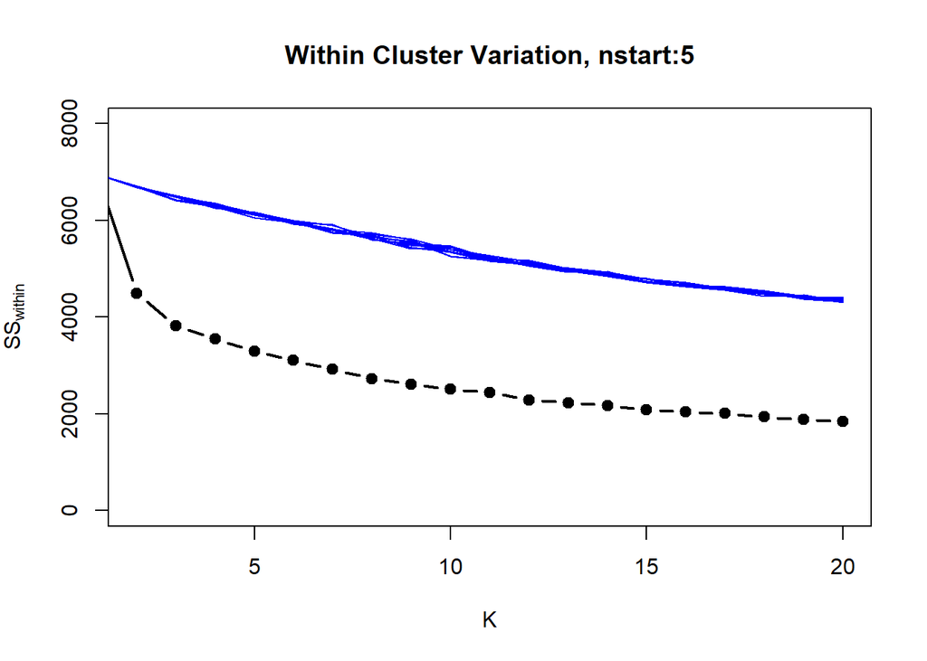

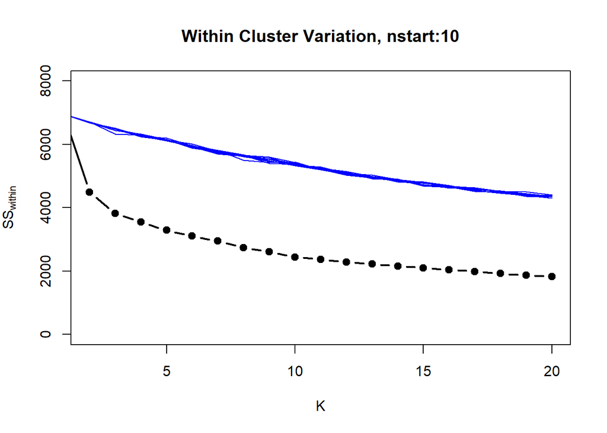

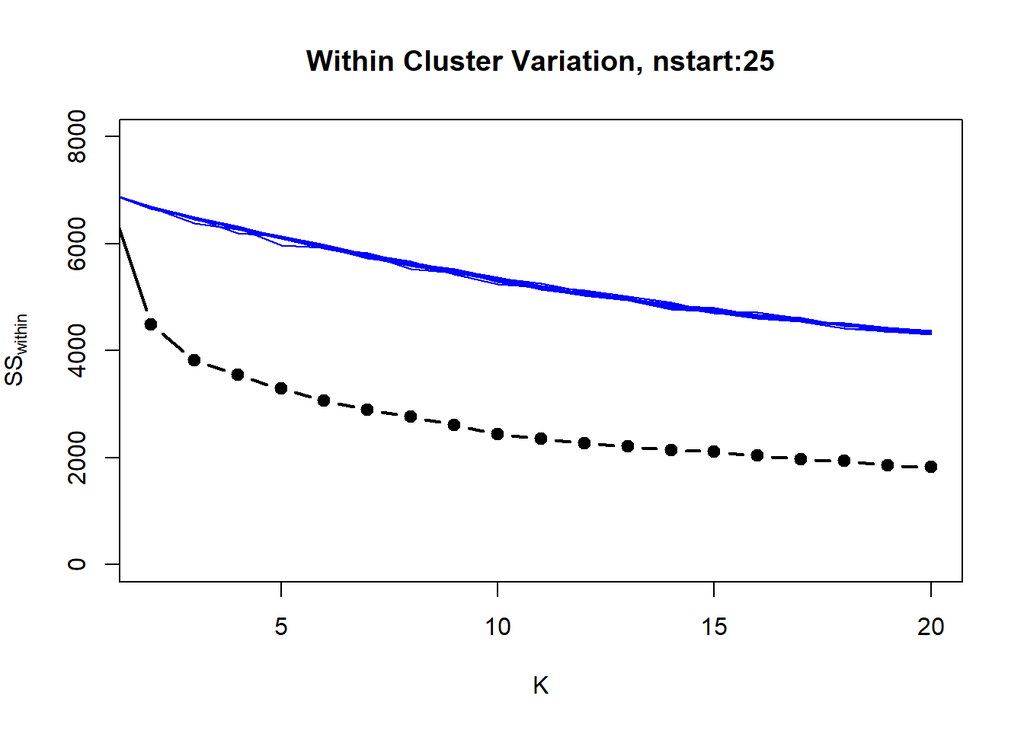

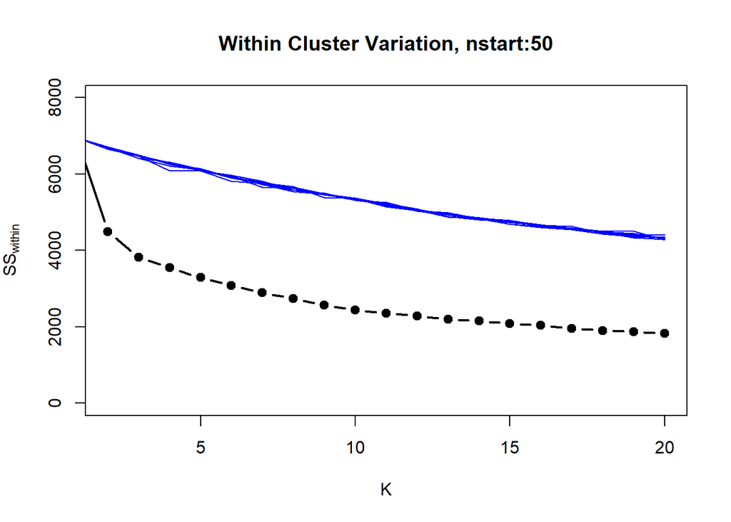

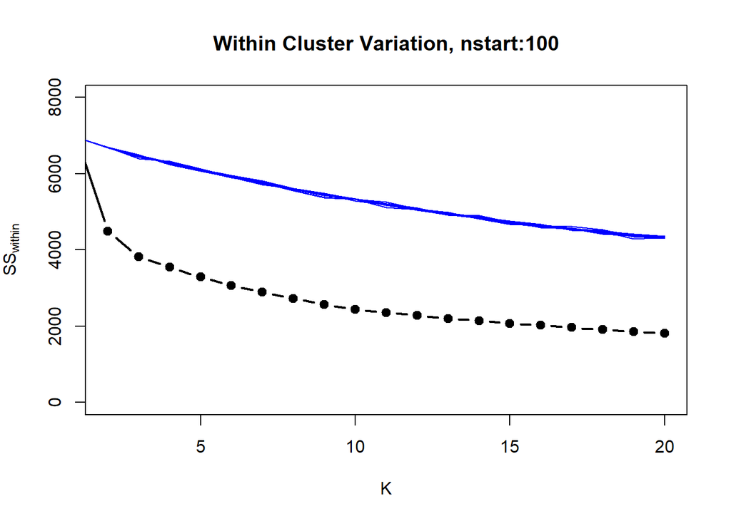

```r
#set.seed(112)
nstarts <- c(5,10,25,50,100)
for (j in nstarts) {
    w=numeric(20)
    for ( k in 1:20 ) {
        kf=kmeans(scaled.data,k,iter.max = 30,nstart=j)
        w[k] = kf$tot.withinss
    }
    plot(1:20,w,
         type="b",lwd=2,pch=19,
         xlab="K", ylab=expression(SS[within]),
         ylim = c(0,8000), xlim = c(2,20),
         main = paste0("Within Cluster Variation, nstart:",j))

    for ( i in 1:10 ) {
        wrnd = numeric()
        wsmpl = numeric()
        for ( k in 1:20 ) {
            krnd = kmeans(apply(scaled.data,2,
                                function(x){
                                    runif(length(x),min(x),max(x))}),
                          k,iter.max = 30,nstart=j)
            ksmpl = kmeans(apply(scaled.data,2,sample),k,iter.max = 30,nstart=j)
            wrnd[k] = krnd$tot.withinss
            wsmpl[k] = ksmpl$tot.withinss
        }
        points(wrnd,type="l",col="red")
        points(wsmpl,type="l",col="blue")
    }
}
```

The curves appears highly stable across the range of nstart values from 5 - 100. After several runs, the inference of K=3 is also very stable.

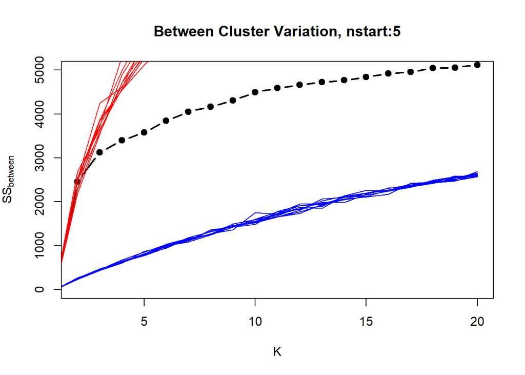

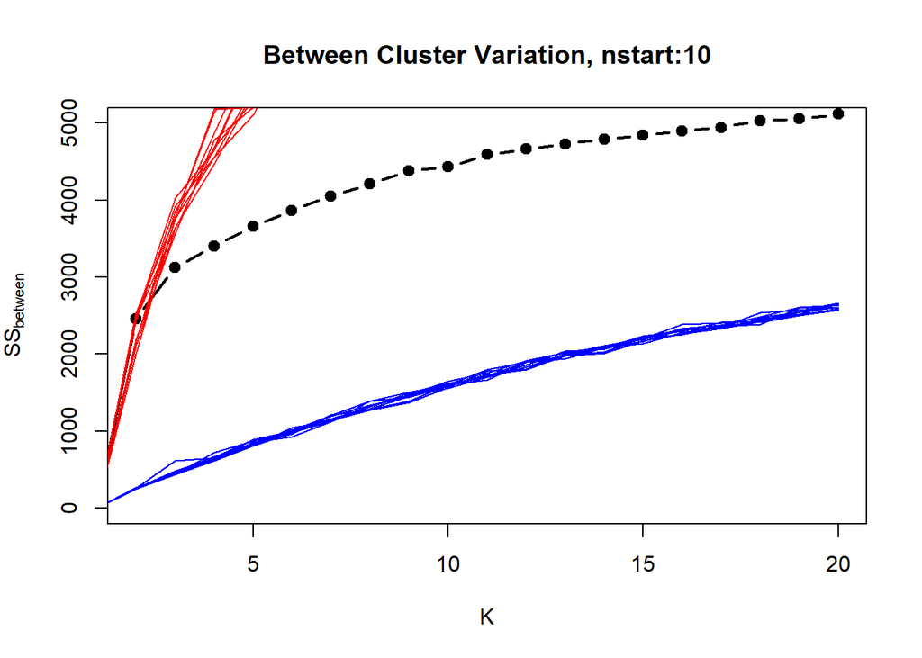

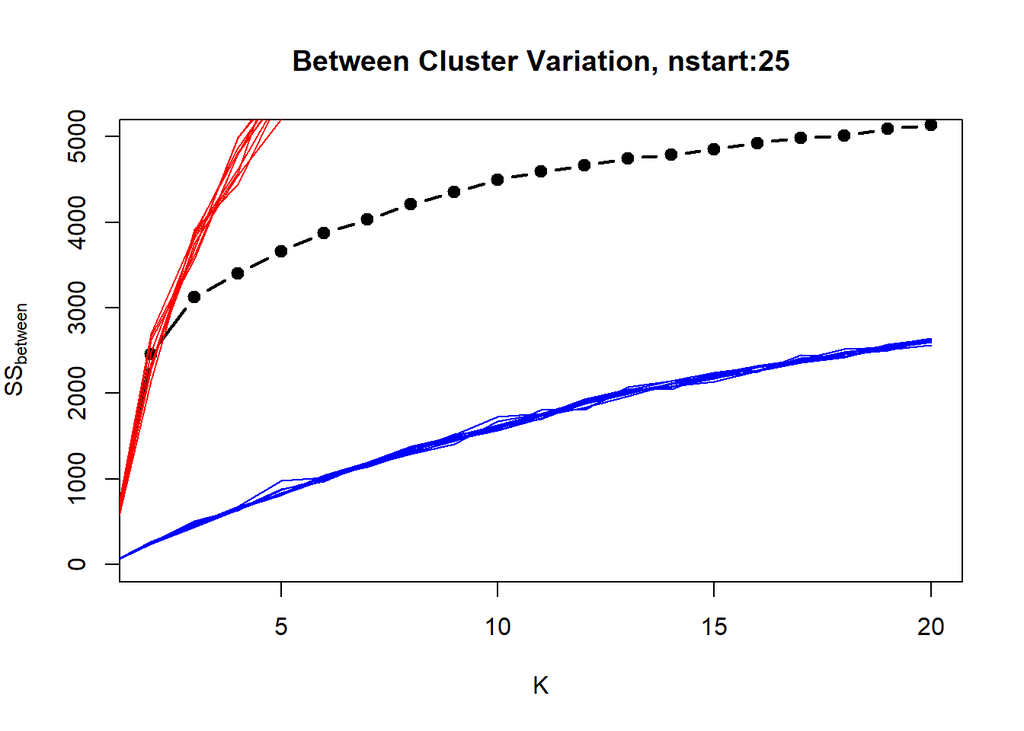

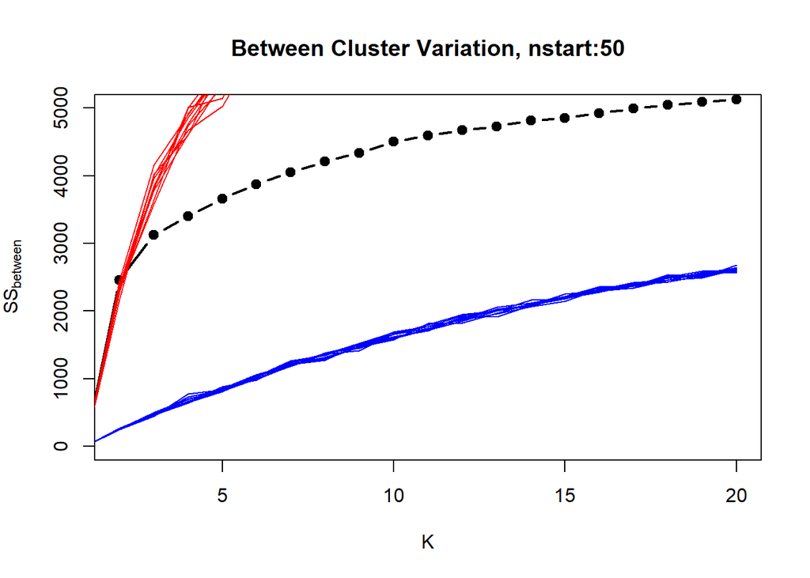

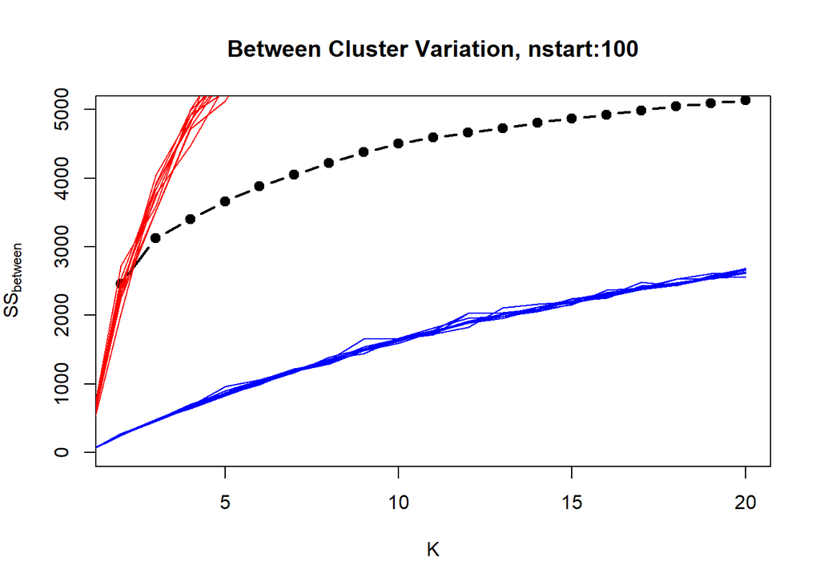

```r
nstarts <- c(5,10,25,50,100)
for (j in nstarts) {
    btw=numeric(20)
    for ( k in 1:20 ) {
        kf=kmeans(scaled.data,k,iter.max = 30,nstart=j)
        btw[k] = kf$betweenss
    }
    plot(1:20,btw,
         type="b",lwd=2,pch=19,
         xlab="K",ylab=expression(SS[between]),
         ylim=c(0,5000),xlim = c(2,20),
         main = paste0("Between Cluster Variation, nstart:",j))

    for ( i in 1:10 ) {
        btwrnd = numeric()
        btwsmpl = numeric()
        for ( k in 1:20 ) {
            krnd = kmeans(apply(scaled.data,2,
                                function(x){
                                    runif(length(x),min(x),max(x))}),
                          k,iter.max = 30,nstart=j)
            ksmpl = kmeans(apply(scaled.data,2,sample),k,iter.max = 30,nstart=j)
            btwrnd[k] = krnd$betweenss
            btwsmpl[k] = ksmpl$betweenss
        }
    points(btwrnd,type="l",col="red")
    points(btwsmpl,type="l",col="blue")
    }
}
```

For the between cluster variation, there is a little less stability across nstart values. Using an n greater than 10 seems to increase stability.

The elbow for this method appears at K=3. Additional K’s after this just incrementally increase the value of the variation. You can see a very distinct break from red line at K=3 as well further confirming the number of clusters is valid.

After several runs, the inference that K=3 is also stable.

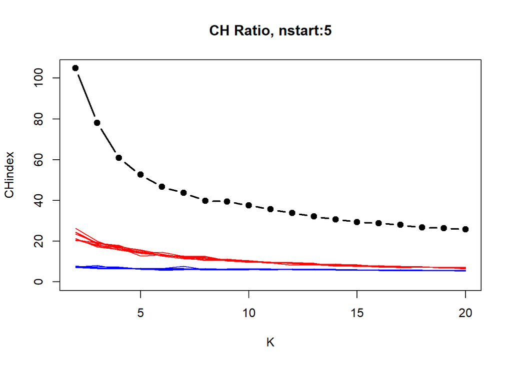

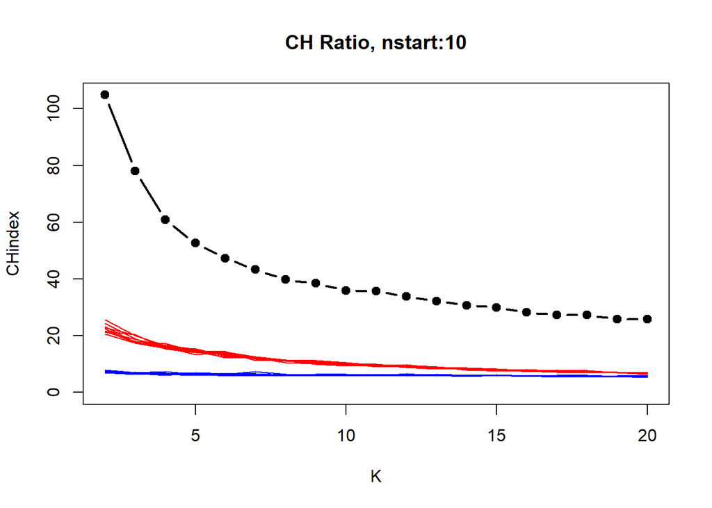

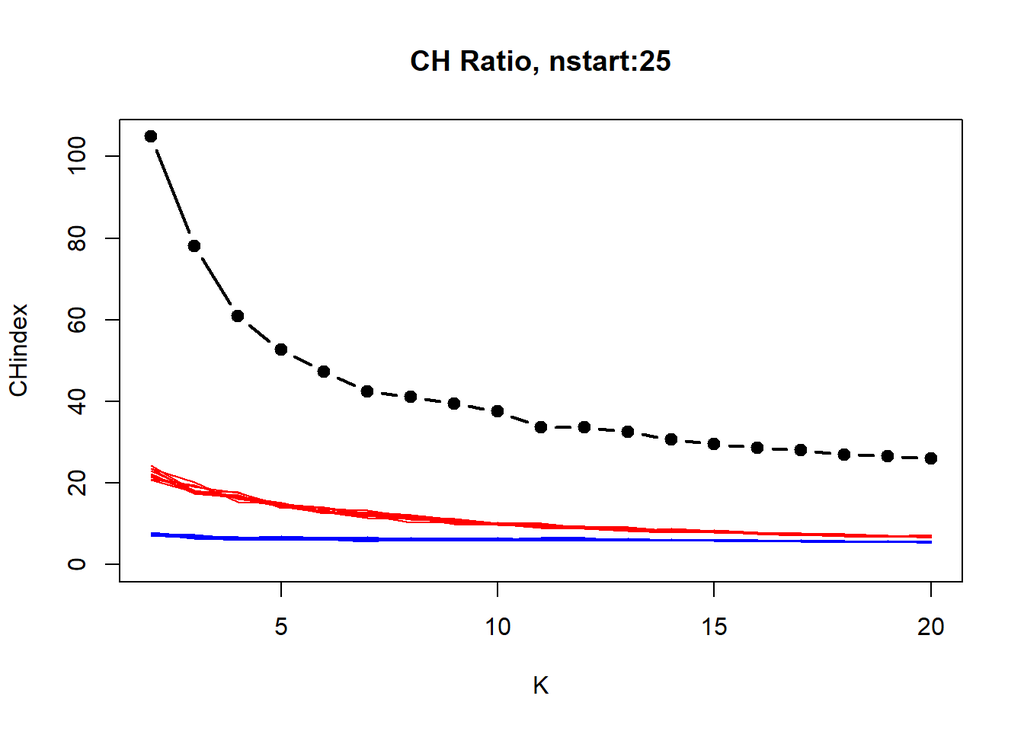

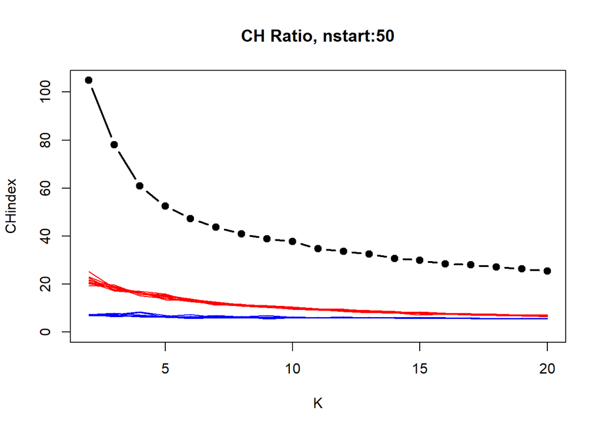

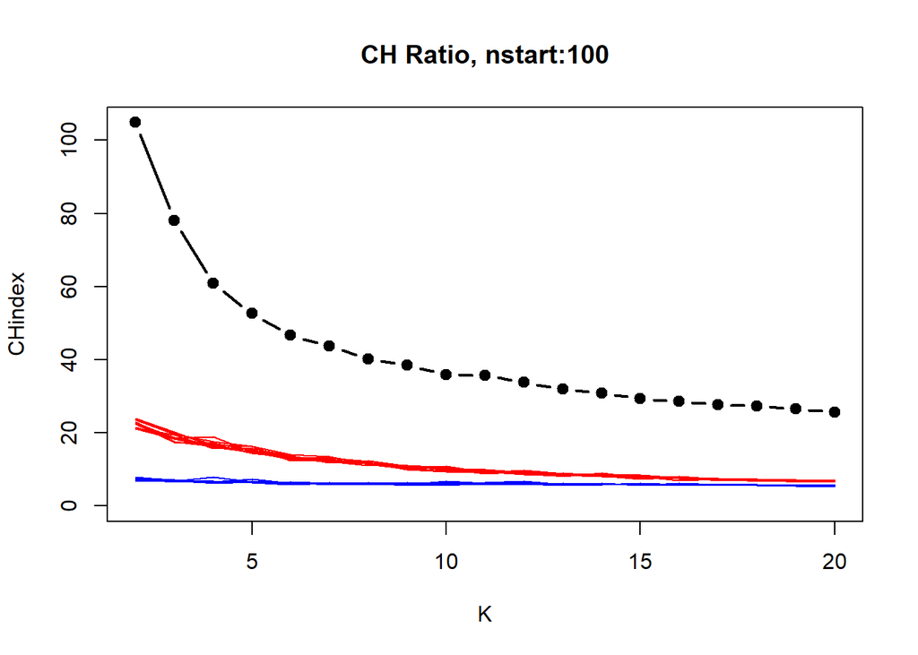

```r
nstarts <- c(5,10,25,50,100)
for (j in nstarts) {
    chori=numeric(20)
    for ( k in 2:20 ) {
        kf=kmeans(scaled.data,k,iter.max = 30,nstart=10)
        chori[k] = (kf$betweenss/(k-1)) /
            (kf$tot.withinss/(nrow(scaled.data)-k))
    }
    plot(2:20,chori[-1],type="b", lwd=2,pch=19,xlab="K", ylab="CHindex",ylim=range(chori[-1])*c(0,1),xlim = c(2,20),
         main = paste0("CH Ratio, nstart:",j))

    for ( i in 1:10 ) {
        chrnd = numeric()
        chsmpl = numeric()
        for ( k in 2:20 ) {
            krnd = kmeans(apply(scaled.data,2,
                                function(x){
                                    runif(length(x),min(x),max(x))}),
                          k,iter.max = 30,nstart=10)
            chrnd[k] = (krnd$betweenss/(k-1)) /
                (krnd$tot.withinss/(nrow(scaled.data)-k))
            ksmpl = kmeans(apply(scaled.data,2,sample),
                           k,iter.max = 30,nstart=10)
            chsmpl[k] = (ksmpl$betweenss/(k-1)) /
                (ksmpl$tot.withinss/(nrow(scaled.data)-k))
        }
    points(2:20,chrnd[-1],type="l",col="red")
    points(2:20,chsmpl[-1],type="l",col="blue")
    }
}
```

The elbow for this method appears at K=4. Additional K’s after this just incrementally decrease the value of CH index.

After several runs, the inference that K=4 is also stable.

Let’s try replotting with K=3 and K=4.

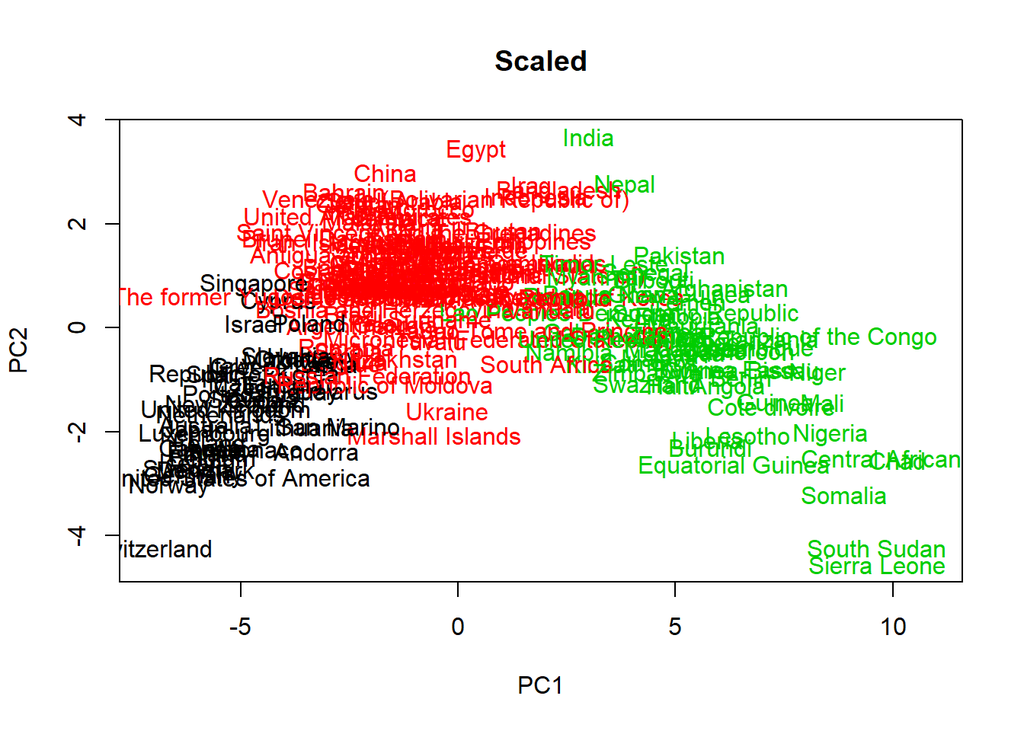

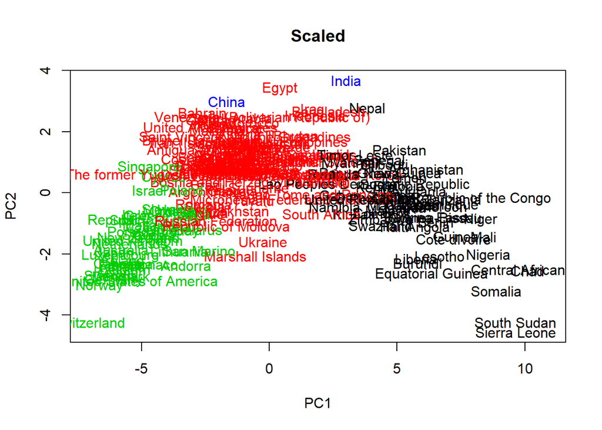

```r
for (i in 3:4) {
    cids <- kmeans(scaled.data,centers=i,nstart=100, iter.max = 30)$cluster
    plot(pcaResTmp$x[,1:2],type="n",main="Scaled")
    text(pcaResTmp$x[,1:2],rownames(pcaResTmp$x),col=cids,pch=15+cids)
}
```

Visually, the 4th cluster does not appear to make much sense. It seems to have grouped two outlier values together as a cluster. Based on this I conclude that the inferences from the between and within cluster variance are accurate and that K=3.

This conclustion was stable across multiple runs and values of nstart greater than 10.

# Problem 2: gap statistics (15 points)

Using the code provided in the lecture slides for calculating gap statistics or one of its implementations available in R (e.g. `clusGap` from library `cluster`), compute and plot gap statistics for K-means clustering of the scaled WHS data for 2 through 20 clusters. Discuss whether it indicates presence of clearly defined cluster structure in this data.

```r
cgScaled <- clusGap(scaled.data,FUN = kmeans,K.max=20,
                    B=500,d.power=2,spaceH0 = "scaledPCA",
                    nstart=100, iter.max=30)
head(cgScaled$Tab)
```

```
##          logW   E.logW      gap     SE.sim
## [1,] 8.153062 9.453574 1.300512 0.02070921
## [2,] 7.717272 9.278982 1.561709 0.01967093
## [3,] 7.555127 9.170990 1.615863 0.01826602
## [4,] 7.479837 9.095427 1.615590 0.01748708
## [5,] 7.404547 9.037670 1.633124 0.01674550
## [6,] 7.336411 8.989777 1.653365 0.01586405
```

```r
maxSE(cgScaled$Tab[,"gap"],cgScaled$Tab[,"SE.sim"])
```

```
## [1] 3
```

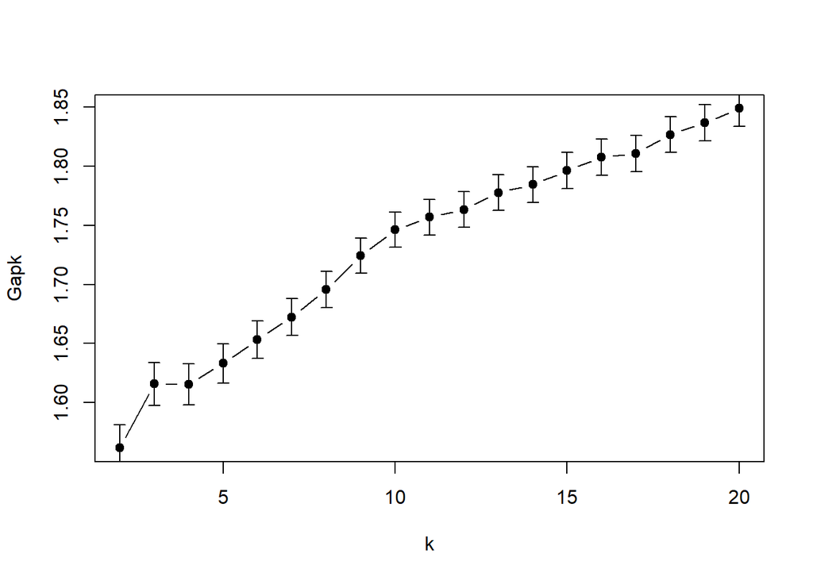

```r
plot(2:20,cgScaled$Tab[2:20,"gap"], pch=19, type="b", xlab = "k", ylab = "Gapk")
arrows(2:20, cgScaled$Tab[2:20,"gap"] - cgScaled$Tab[2:20,"SE.sim"], 2:20, cgScaled$Tab[2:20,"gap"] + cgScaled$Tab[2:20,"SE.sim"],
       length = 0.05, angle = 90, code = 3)
```

After multiple runs at the default boostrap value of 100 and stable nstart value of 100, I noticed that the local maximum would change between k=3 and k=4. The gap values were very similar to each other, differing by 0.001. In order to get a more accurate and stable local maximum, I increased the number of bootstrap runs to 500. I was able to achieve a consistent result of the local maximum occuring at k=3 for 2 runs. I will note that the SE bars for k=3 and k=4 are very similar as well however you can see that the k=4 se bars are slightly lower than k=3 which also lends evidence to the local maximum being at k=3. Repeated runs will likely continue to vary slightly because the se bars overlap so much.

# Problem 3: stability of hierarchical clustering (15 points)

For numbers of clusters K=2, 3 and 4 found in the scaled WHS dataset by (1) `hclust` with Ward method (as obtained by `cutree` at corresponding levels of `k`) and (2) by K-means, compare cluster memberships between these two methods at each K and describe their concordance. This problem is similar to the one from week 8 problem set, but this time it is *required* to: 1) use two dimensional contingency tables implemented by `table` to compare membership between two assignments of observations into clusters, and 2) programmatically re-order rows and columns in the `table` result to correctly identify the correspondence between the clusters (please see examples in lecture slides).

```r
dist.scaled.data <- dist(scaled.data)
heir <- hclust(dist.scaled.data, method = "ward.D2")
```

```r
library(clue)
matrix.sort <- function(m) {
    require(clue)
    p = solve_LSAP(m, maximum=TRUE)
    m[,p]
}

cmp.shortcut <- function(kdata,heirdata,K,nstart=100,iter.max=30,...) {
    matrix.sort(table(
        kmeans(kdata, K, ...)$cluster,
        cutree(heirdata, K, ...)))
}
```

```r
for (i in 2:4) {
    print(cmp.shortcut(scaled.data, heir, i))
}
```

```
##
##       1   2
##   1  63   1
##   2   6 124
##
##      3  2  1
##   1 44  0  0
##   2 10 71 15
##   3  0  0 54
##
##      1  2  4  3
##   1 41  0 12  0
##   2  0 71 14 10
##   3  0  0  2  0
##   4  0  0  0 44
```

The contingency tables show along their diagonals the number of contries that appeared in the same cluster between the two methods. This means we want to see higher numbers along the diagonal and lower numbers off of the diagonal which is our case above.

In the k=2 comparison, we see only 7 total countries are inconsistently assigned to groups.

In the k=3 comparison, we see four “0” values off the diagonal which is a very good result. However there are still 25 countries total that have inconsistent cluster assignments between the two methods. In this example, we see just one row that contains the 25 countries which indicates that the discrepancy is limited to just two clusters, not all three.

## For *extra* 5 points: between/within variance in hierarchical clusters

Using functions `between` and `within` provided in the lecture slides calculate between and (total) within cluster variances for top 2 through 20 clusters defined by Ward’s hierarchical clustering when applied to the scaled WHS data. Plot the results. Compare their behavior to that of the same statistics when obtained for K-means clustering above.

```r
within=function(d,clust ) {
    w=0
    for (i in sort(unique( clust )) ){
        members = d[clust==i,,drop=F]
        centroid = apply(members,2,mean)
        members.diff = sweep(members,2,centroid)
        w = w+sum(members.diff^2)
    }
    return(w)
}

between=function(d, clust) {
    b=0
    total.mean = apply(d,2,mean)
    for (i in sort(unique(clust)) ) {
        members = d[clust==i,,drop=F]
        centroid = apply(members,2,mean)
        b=b+nrow(members)*sum((centroid-total.mean)^2)
    }
    return(b)
}
```

```r
dwithin=numeric()
dbetween=numeric()
for (i in 2:20) {
    hcut <- cutree(heir, i)
    dwithin[i] <- within(scaled.data,hcut)
    dbetween[i] <- between(scaled.data,hcut)
}
```

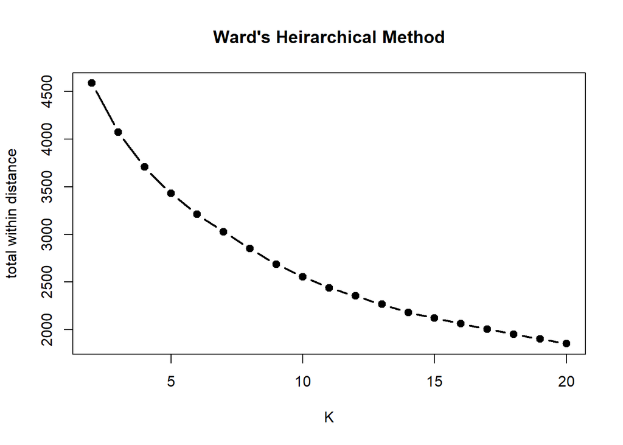

```r
plot(dwithin,type="b", lwd=2,pch=19,xlab="K", ylab="total within distance",
     xlim = c(2,20),main = "Ward's Heirarchical Method")
```

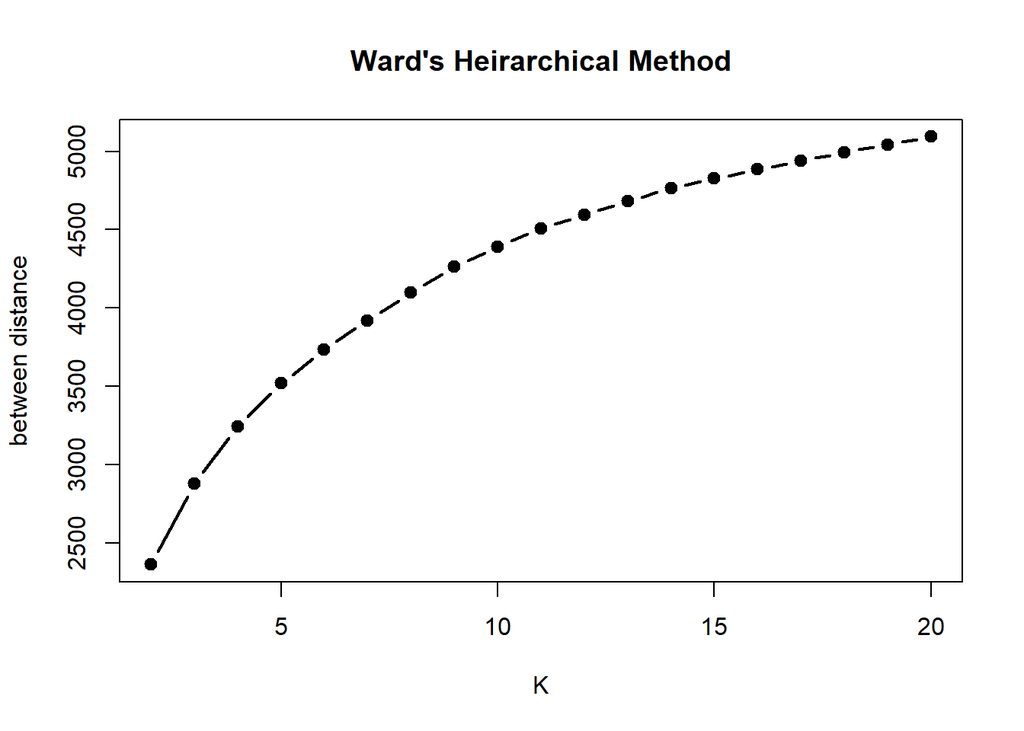

```r
plot(dbetween,type="b", lwd=2,pch=19,xlab="K", ylab="between distance",
     xlim = c(2,20),main = "Ward's Heirarchical Method")
```

Both curves look very smooth and it makes it very hard to discern an elbow. You can see the distance between the plotted points decreasing as k increases however but it is much more subtle than the elbow. The line distance between the plotted points appears to change very little after about k=4 in both graphs.

The values of the plotted points in the y-axis (the total distances) are consistent with the plots obtained in part one.

# Problem 4: Brute force randomization in hierarchical clustering (15 points)

Compare distribution of the heights of the clusters defined by `hclust` with Ward’s clustering of Euclidean distance between countries in the scaled WHS dataset and those obtained by applying the same approach to the distances calculated on randomly permuted WHS dataset as illustrated in the lecture slides. Discuss whether results of such brute force randomization are supportive of presence of unusually close or distant sets of observations within WHS data.

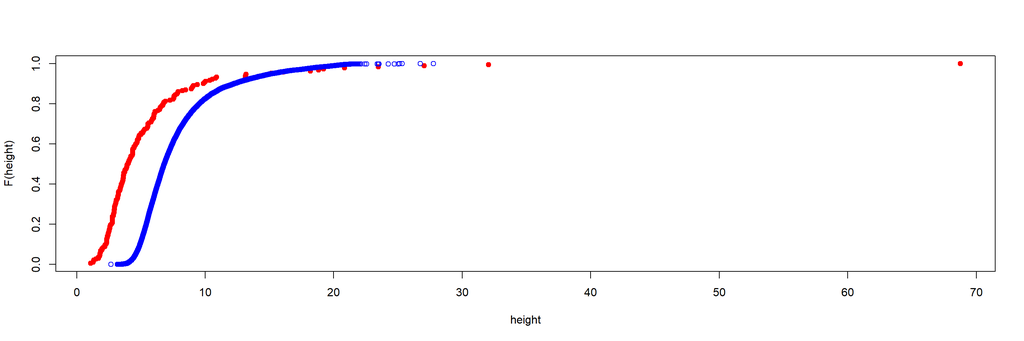

```r
ori.heights= heir$height
rnd.heights= numeric()
for (i.sim in 1:100 ) {
  data.rnd<-apply(scaled.data,2,sample)
  hw.rnd=hclust(dist(data.rnd ),method="ward.D2")
  rnd.heights<-c( rnd.heights,hw.rnd$height)
}
plot(ori.heights,rank(ori.heights )/ length(ori.heights),
     col="red",xlab ="height", ylab ="F(height)", pch =19)
points(rnd.heights,rank(rnd.heights)/length(rnd.heights),col="blue")
```

The above plot indicates that the outliers for height occur after about 30. Looking at the heirarchy below, a horizontal line at height=30 would cross three heirarchy lines therefore this method indicates that k=3.

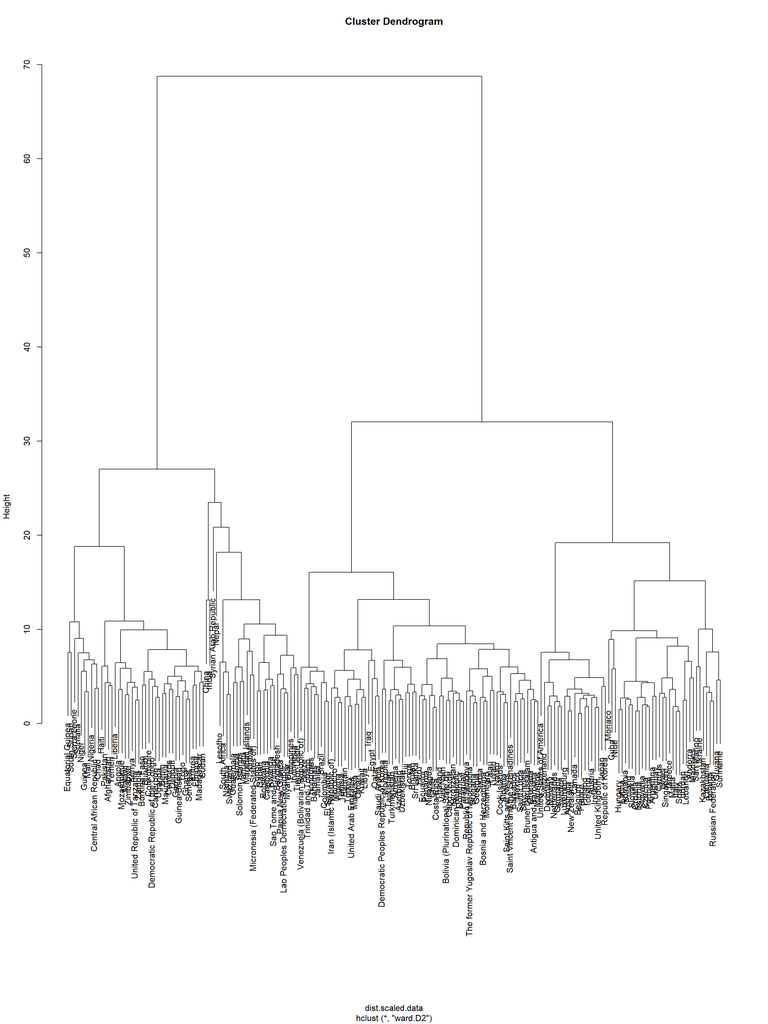

```r
plot(heir)
```